# Lab 5.2: Working with Entities

## 6. Using word clouds and ngrams

(Go to top)

While Amazon Comprehend is processing the data and the OpenSearch cluster is being provisioned, you can explore some other techniques. In this section, you will create a word cloud from the plot text and then look at different ngrams to extract key phrases.

```python
df2 = pd.read_csv('../data/plot_summaries.tsv', sep='\t', names=['movie_id','plot'])
df2 = df2.head(4000)
df2.head()
```

|  | movie_id | plot |
| --- | --- | --- |
| 0 | 23890098 | Shlykov, a hard-working taxi driver and Lyosha, a saxophonist, develop a bizarre love-hate relationship, and despite their prejudices, realize the... |
| 1 | 31186339 | The nation of Panem consists of a wealthy Capitol and twelve poorer districts. As punishment for a past rebellion, each district must provide a bo... |
| 2 | 20663735 | Poovalli Induchoodan is sentenced for six years prison life for murdering his classmate. Induchoodan, the only son of Justice Maranchery Karunaka... |
| 3 | 2231378 | The Lemon Drop Kid , a New York City swindler, is illegally touting horses at a Florida racetrack. After several successful hustles, the Kid comes... |
| 4 | 595909 | Seventh-day Adventist Church pastor Michael Chamberlain, his wife Lindy, their two sons, and their nine-week-old daughter Azaria are on a camping ... |

Now load the stopwords for the English language.

```python
stop_words = set(stopwords.words("english"))
```

```python
df2.get('plot')
```

```
0       Shlykov, a hard-working taxi driver and Lyosha, a saxophonist, develop a bizarre love-hate relationship, and despite their prejudices, realize the...
1       The nation of Panem consists of a wealthy Capitol and twelve poorer districts. As punishment for a past rebellion, each district must provide a bo...
2       Poovalli Induchoodan  is sentenced for six years prison life for murdering his classmate. Induchoodan, the only son of Justice Maranchery Karunaka...
3       The Lemon Drop Kid , a New York City swindler, is illegally touting horses at a Florida racetrack. After several successful hustles, the Kid comes...
4       Seventh-day Adventist Church pastor Michael Chamberlain, his wife Lindy, their two sons, and their nine-week-old daughter Azaria are on a camping ...
                                                                                ...
3995    In this tragic tale of misunderstanding, obsession, and increasing madness, "Elle," a beautiful young woman  settles into a small town in the sout...
3996    The hero of the film is living as a businessman working for an investment company, but in the past was a KGB special agent known as Icarus. He tri...
3997    Christmas card salesman Stan and Ollie are persuaded to help a woman  spice up her loveless marriage by making her husband jealous. The spouse inv...
3998    As the narrator invites us to explore the horrors of an insane mind, a young woman wakes from a nightmare in a cheap hotel room. We follow her thr...
3999    Drew Baylor  is the designer of the Späsmodica shoe, a world-famously hyped but flawed new product that his boss informs him will lose $972 millio...
Name: plot, Length: 4000, dtype: object
```

To normalize the text, use the same cleaning script that you used earlier. A few additional characters are removed in order to improve the word cloud. This cleaning script stores the output in an array.

```python
corpus = []

for i in range(0, df2.shape[0]):
    # Remove URLs
    text = re.sub(r"http\S+", "", df2['plot'][i])
    # Remove punctuation
    text = re.sub('[^a-zA-Z]', ' ', text)

    text = text.lower() # Lowercase all letters
    text = text.strip() # Remove leading/trailing whitespace
    text = re.sub('\s+', ' ', text) # Remove extra spaces and tabs
    text = re.compile('<.*?>').sub('', text) # Remove HTML tags/markup

    # Remove special characters and digits
    text=re.sub("(\\d|\\W)+"," ",text)
    text=re.sub("br","",text)

    ##Convert to list from string
    text = text.split()

    ##Stemming
    lem = WordNetLemmatizer()
    text = [lem.lemmatize(word) for word in text if not word in stop_words]
    text = " ".join(text)
    corpus.append(text)
```

To make a word cloud, install the wordcloud package. Then, run the corpus through the WordCloud constructor.

```python
!pip install wordcloud
```

```
  Obtaining dependency information for wordcloud from https://files.pythonhosted.org/packages/22/0d/bb4eccd60d272b33cbc79c661c60acc604f1688cfc922deb9d3eb5be640a/wordcloud-1.9.2-cp310-cp310-manylinux_2_17_x86_64.manylinux2014_x86_64.whl.metadata
Downloading wordcloud-1.9.2-cp310-cp310-manylinux_2_17_x86_64.manylinux2014_x86_64.whl (455 kB)
   ━━━━━━━━━━━━━━━━━━━━━━━━━━━━━━━━━━━━━━━━ 455.4/455.4 kB 4.1 MB/s eta 0:00:00:00:01
```

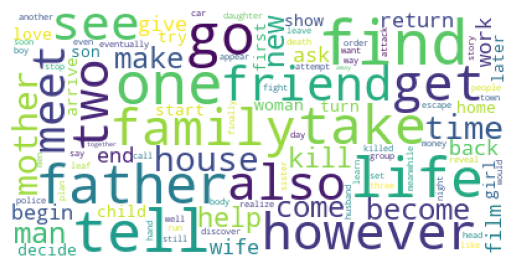

```python
from os import path
from PIL import Image
from wordcloud import WordCloud, STOPWORDS, ImageColorGenerator
import matplotlib.pyplot as plta

%matplotlib inline
wordcloud = WordCloud(
                          background_color='white',
                          stopwords=stop_words,
                          max_words=100,
                          max_font_size=50,
                          random_state=42
                         ).generate(str(corpus))

fig = plt.figure(1)
plt.imshow(wordcloud)
plt.axis('off')
plt.show()
fig.savefig("word1.png", dpi=900)
```

Another way to evaluate the text is to create a bar chart of the most frequently occuring words. The next several cells will do the following: - create a vector for the terms - create a bag of words model based on the dataset - create an array of the most frequent words - load the most frequent words into a DataFrame - create a bar chart from the DataFrame

```python
%%time
from sklearn.feature_extraction.text import CountVectorizer
import re

cv=CountVectorizer(max_df=0.8,stop_words=stop_words, max_features=10000, ngram_range=(1,3))

X=cv.fit_transform(corpus)
```

[output not shown]

```python
# Get the most frequently occurring words
def get_top_n_words(corpus, n=None, size=1):
    vec = CountVectorizer(ngram_range=(size,size), max_features=2000).fit(corpus)
    bag_of_words = vec.transform(corpus)
    sum_words = bag_of_words.sum(axis=0)
    words_freq = [(word, sum_words[0, idx]) for word, idx in
                   vec.vocabulary_.items()]
    words_freq =sorted(words_freq, key = lambda x: x[1],
                       reverse=True)
    return words_freq[:n]
```

```
CPU times: user 1.08 s, sys: 3.91 ms, total: 1.09 s
Wall time: 1.28 s
```

```
[Text(0, 0, 'one'),
```

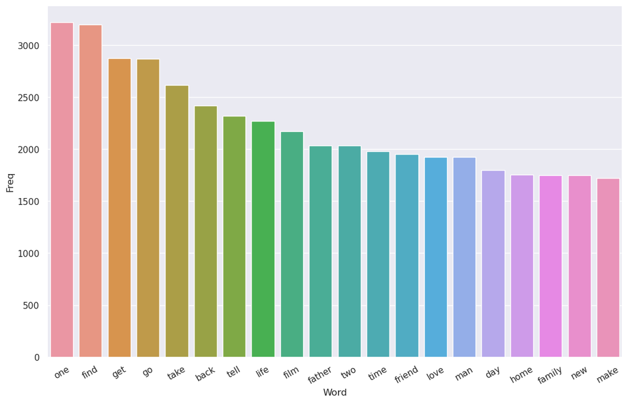

```python
%%time
# Convert the most frequent words to a DataFrame
top_words = get_top_n_words(corpus, n=20)
top_df = pd.DataFrame(top_words)
top_df.columns=["Word", "Freq"]

# Create a bar plot

sns.set(rc={'figure.figsize':(13,8)})
g = sns.barplot(x="Word", y="Freq", data=top_df)
g.set_xticklabels(g.get_xticklabels(), rotation=30)
```

```
[Text(0, 0, 'fall love'),
```

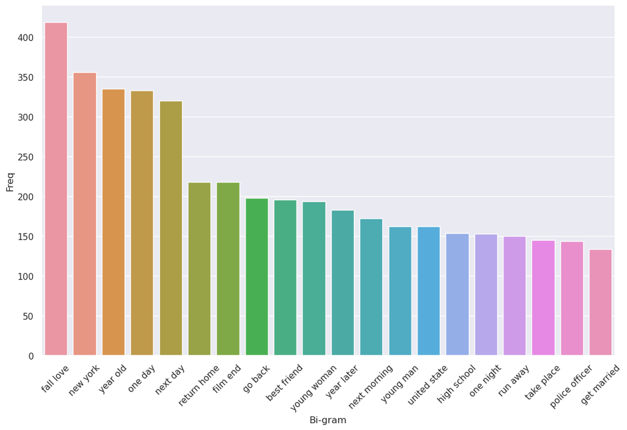

```python
# Get the most frequently occurring bi-grams
top2_words = get_top_n_words(corpus, n=20, size=2)
top2_df = pd.DataFrame(top2_words)
top2_df.columns=["Bi-gram", "Freq"]

# Create a bar plot
sns.set(rc={'figure.figsize':(13,8)})
h=sns.barplot(x="Bi-gram", y="Freq", data=top2_df)
h.set_xticklabels(h.get_xticklabels(), rotation=45)
```

```
CPU times: user 3.34 s, sys: 103 ms, total: 3.45 s
Wall time: 3.45 s
```

```
[Text(0, 0, 'new york city'),
```

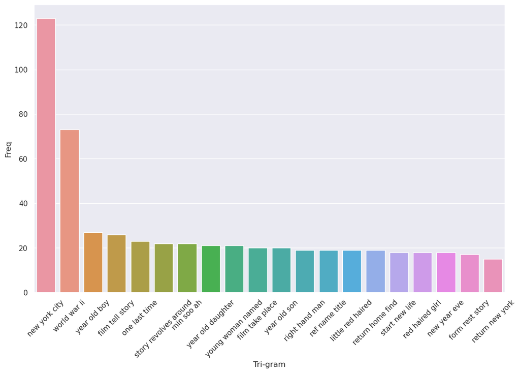

```python
%%time

# Get the most frequently occurring tri-grams
top3_words = get_top_n_words(corpus, n=20, size=3)
top3_df = pd.DataFrame(top3_words)
top3_df.columns=["Tri-gram", "Freq"]

# Create a bar plot
sns.set(rc={'figure.figsize':(13,8)})
j=sns.barplot(x="Tri-gram", y="Freq", data=top3_df)
j.set_xticklabels(j.get_xticklabels(), rotation=45)
```

```
                               Four-gram  Freq
0                 little red haired girl    18
1                      cite web cite web     9
2                   return new york city     8
3                      cai mao zhang yun     7
4                  fall love first sight     7
5                    ref name title work     7
6                     name title work ny     7
7                     title work ny time     7
8                     move new york city     6
9                     life new york city     6
10                       yap yap yap yap     6
11                      dr chase dr macy     6
12               synopsis based cite web     5
13            strange thing begin happen     5
14      ref nameweisser firstyuko mihara     5
15  nameweisser firstyuko mihara weisser     5
16        firstyuko mihara weisser title     5
17              decides take matter hand     5
18                 year event first film     5
19                    new year eve party     5
CPU times: user 3.33 s, sys: 91.6 ms, total: 3.42 s
Wall time: 3.42 s
```

```
[Text(0, 0, 'little red haired girl'),
```

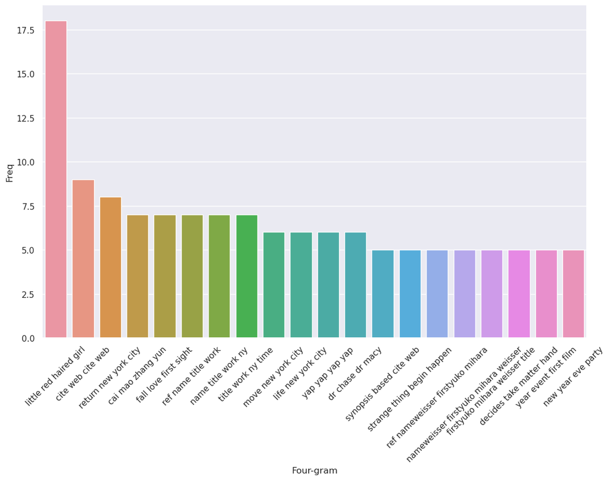

```python
%%time
# Get the most frequently occurring 4-grams
top4_words = get_top_n_words(corpus, n=20, size=4)
top4_df = pd.DataFrame(top4_words)
top4_df.columns=["Four-gram", "Freq"]
print(top4_df)

# Create a bar plot
sns.set(rc={'figure.figsize':(13,8)})
j=sns.barplot(x="Four-gram", y="Freq", data=top4_df)
j.set_xticklabels(j.get_xticklabels(), rotation=45)
```

## 7. Returning to Amazon Comprehend

(Go to top)

The Amazon Comprehend jobs are probably complete now. To check, use the next two cells.

```python
# Get current job status
kpe_job = comprehend_client.describe_key_phrases_detection_job(JobId=kpe_job_id)

# Loop until job is completed
waited = 0
timeout_minutes = 30
while kpe_job['KeyPhrasesDetectionJobProperties']['JobStatus'] != 'COMPLETED':
    sleep(10)
    waited += 10
    assert waited//60 < timeout_minutes, "Job timed out after %d seconds." % waited
    print('.', end='')
    kpe_job = comprehend_client.describe_key_phrases_detection_job(JobId=kpe_job_id)

print('Ready')
```

```
............................................................................................................................Ready
```

```python
# Get current job status
entity_job = comprehend_client.describe_entities_detection_job(JobId=entity_job_id)

# Loop until job is completed
waited = 0
timeout_minutes = 30
while entity_job['EntitiesDetectionJobProperties']['JobStatus'] != 'COMPLETED':
    sleep(10)
    waited += 10
    assert waited//60 < timeout_minutes, "Job timed out after %d seconds." % waited
    print('.', end='')
    entity_job = comprehend_client.describe_entities_detection_job(JobId=entity_job_id)

print('Ready')
```

```
Ready
```

When both cells print "Ready," proceed to the next step.

To get the output for the key phrases detection job, extract the output location from the job and download it to the file system.

```python
kpe_comprehend_output_file = kpe_job['KeyPhrasesDetectionJobProperties']['OutputDataConfig']['S3Uri']
print(f'output filename: {kpe_comprehend_output_file}')

kpe_comprehend_bucket, kpe_comprehend_key = kpe_comprehend_output_file.replace("s3://", "").split("/", 1)

s3r = boto3.resource('s3')
s3r.meta.client.download_file(kpe_comprehend_bucket, kpe_comprehend_key, 'output-kpe.tar.gz')
```

```
output filename: s3://c96181a2162104l4831713t1w225468853486-labbucket-1phsagx47cncv/225468853486-KP-2190003982ffeaa05be14ea35b14c78e/output/output.tar.gz
```

Next, extract the file and rename the output so you know which file this is.

```python
# Extract the tar file
import tarfile
tf = tarfile.open('output-kpe.tar.gz')
tf.extractall()
# Rename the output
!mv 'output' 'kpe_output'
```

Repeat these steps for the entity detection job.

```python
entity_comprehend_output_file = entity_job['EntitiesDetectionJobProperties']['OutputDataConfig']['S3Uri']
print(f'output filename: {entity_comprehend_output_file}')

entity_comprehend_bucket, entity_comprehend_key = entity_comprehend_output_file.replace("s3://", "").split("/", 1)

s3r = boto3.resource('s3')
s3r.meta.client.download_file(entity_comprehend_bucket, entity_comprehend_key, 'output-entity.tar.gz')

# Extract the tar file
import tarfile
tf = tarfile.open('output-entity.tar.gz')
tf.extractall()
# Rename the output
!mv 'output' 'entity_output'
```

```
output filename: s3://c96181a2162104l4831713t1w225468853486-labbucket-1phsagx47cncv/225468853486-NER-6ccfda91ab806b6de181dea491b2b1cf/output/output.tar.gz
```

Read the data from the key phrases file into an array.

```python
import json
data = []
with open ('kpe_output', "r") as myfile:
    for line in myfile:
        data.append(json.loads(line))
```

Load the data array into a DataFrame. There are two columns: **KeyPhrases** and **Line**.

```python
kpdf = pd.DataFrame(data, columns=['KeyPhrases','Line'])
kpdf.head()
```

|  | KeyPhrases | Line |
| --- | --- | --- |
| 0 | [{'BeginOffset': 1, 'EndOffset': 19, 'Score': 0.9427363954842535, 'Text': 'the lemon drop kid'}, {'BeginOffset': 22, 'EndOffset': 46, 'Score': 0.9... | 3 |
| 1 | [{'BeginOffset': 1, 'EndOffset': 8, 'Score': 0.7637239606349573, 'Text': 'shlykov'}, {'BeginOffset': 10, 'EndOffset': 36, 'Score': 0.9996321098478... | 0 |
| 2 | [{'BeginOffset': 1, 'EndOffset': 11, 'Score': 0.9951175812596029, 'Text': 'the nation'}, {'BeginOffset': 15, 'EndOffset': 20, 'Score': 0.998997978... | 1 |
| 3 | [{'BeginOffset': 1, 'EndOffset': 14, 'Score': 0.9986818707743575, 'Text': 'the president'}, {'BeginOffset': 21, 'EndOffset': 28, 'Score': 0.999917... | 5 |
| 4 | [{'BeginOffset': 1, 'EndOffset': 21, 'Score': 0.9113039918040963, 'Text': 'poovalli induchoodan'}, {'BeginOffset': 39, 'EndOffset': 48, 'Score': 0... | 2 |

Repeat these steps for the entity detection data.

```python
import json
data = []
with open ('entity_output', "r") as myfile:
    for line in myfile:
        data.append(json.loads(line))
```

```python
entitydf = pd.DataFrame(data, columns=['Entities','Line'])
entitydf.head()
```

|  | Entities | Line |
| --- | --- | --- |
| 0 | [{'BeginOffset': 5, 'EndOffset': 15, 'Score': 0.6954694958886258, 'Text': 'lemon drop', 'Type': 'PERSON'}, {'BeginOffset': 24, 'EndOffset': 32, 'S... | 3 |
| 1 | [{'BeginOffset': 1, 'EndOffset': 8, 'Score': 0.9199824601599764, 'Text': 'shlykov', 'Type': 'PERSON'}, {'BeginOffset': 41, 'EndOffset': 47, 'Score... | 0 |
| 2 | [{'BeginOffset': 15, 'EndOffset': 20, 'Score': 0.8679950589581368, 'Text': 'panem', 'Type': 'LOCATION'}, {'BeginOffset': 55, 'EndOffset': 78, 'Sco... | 1 |
| 3 | [{'BeginOffset': 269, 'EndOffset': 280, 'Score': 0.965448054177801, 'Text': 'alex thomas', 'Type': 'PERSON'}, {'BeginOffset': 362, 'EndOffset': 36... | 5 |
| 4 | [{'BeginOffset': 1, 'EndOffset': 21, 'Score': 0.8154202182251195, 'Text': 'poovalli induchoodan', 'Type': 'PERSON'}, {'BeginOffset': 39, 'EndOffse... | 2 |

Review the entity detection data. Notice that the different detected entities, such as Person or Title, are buried in the same fields.

Depending on your scenario, you may want to split this out into separate columns for each entity type. To do this, you can write a function.

```python
def extract_entities(entities, entity_type):
    filtered_entities=[]
    for entity in entities:
        if entity['Type'] == entity_type:
            filtered_entities.append(entity)
    return filtered_entities
```

Then apply the function to each of the event types that you want to extract.

```python
# df['plot_normalized'] = df['plot'].apply(normalize_text)
entitydf['persons'] = entitydf['Entities'].apply(lambda x: extract_entities(x,'PERSON'))
entitydf['location'] = entitydf['Entities'].apply(lambda x: extract_entities(x, 'LOCATION'))
entitydf['event'] = entitydf['Entities'].apply(lambda x: extract_entities(x, 'EVENT'))
entitydf['organization'] = entitydf['Entities'].apply(lambda x: extract_entities(x, 'ORGANIZATION'))

entitydf.head()
```

|  | Entities | Line | persons | location | event | organization |
| --- | --- | --- | --- | --- | --- | --- |
| 0 | [{'BeginOffset': 5, 'EndOffset': 15, 'Score': 0.6954694958886258, 'Text': 'lemon drop', 'Type': 'PERSON'}, {'BeginOffset': 24, 'EndOffset': 32, 'S... | 3 | [{'BeginOffset': 5, 'EndOffset': 15, 'Score': 0.6954694958886258, 'Text': 'lemon drop', 'Type': 'PERSON'}, {'BeginOffset': 370, 'EndOffset': 375, ... | [{'BeginOffset': 24, 'EndOffset': 32, 'Score': 0.9940149916503278, 'Text': 'new york', 'Type': 'LOCATION'}, {'BeginOffset': 81, 'EndOffset': 88, '... | [{'BeginOffset': 497, 'EndOffset': 506, 'Score': 0.8445764706629427, 'Text': 'christmas', 'Type': 'EVENT'}, {'BeginOffset': 542, 'EndOffset': 550,... | [{'BeginOffset': 2695, 'EndOffset': 2701, 'Score': 0.8372813502905793, 'Text': 'oxford', 'Type': 'ORGANIZATION'}] |
| 1 | [{'BeginOffset': 1, 'EndOffset': 8, 'Score': 0.9199824601599764, 'Text': 'shlykov', 'Type': 'PERSON'}, {'BeginOffset': 41, 'EndOffset': 47, 'Score... | 0 | [{'BeginOffset': 1, 'EndOffset': 8, 'Score': 0.9199824601599764, 'Text': 'shlykov', 'Type': 'PERSON'}, {'BeginOffset': 41, 'EndOffset': 47, 'Score... | [] | [] | [] |
| 2 | [{'BeginOffset': 15, 'EndOffset': 20, 'Score': 0.8679950589581368, 'Text': 'panem', 'Type': 'LOCATION'}, {'BeginOffset': 55, 'EndOffset': 78, 'Sco... | 1 | [{'BeginOffset': 436, 'EndOffset': 443, 'Score': 0.9931286353914209, 'Text': 'katniss', 'Type': 'PERSON'}, {'BeginOffset': 474, 'EndOffset': 487, ... | [{'BeginOffset': 15, 'EndOffset': 20, 'Score': 0.8679950589581368, 'Text': 'panem', 'Type': 'LOCATION'}, {'BeginOffset': 382, 'EndOffset': 390, 'S... | [{'BeginOffset': 4317, 'EndOffset': 4329, 'Score': 0.6990767867186888, 'Text': 'hunger games', 'Type': 'EVENT'}] | [{'BeginOffset': 2524, 'EndOffset': 2530, 'Score': 0.7185639925657864, 'Text': 'seneca', 'Type': 'ORGANIZATION'}] |
| 3 | [{'BeginOffset': 269, 'EndOffset': 280, 'Score': 0.965448054177801, 'Text': 'alex thomas', 'Type': 'PERSON'}, {'BeginOffset': 362, 'EndOffset': 36... | 5 | [{'BeginOffset': 269, 'EndOffset': 280, 'Score': 0.965448054177801, 'Text': 'alex thomas', 'Type': 'PERSON'}, {'BeginOffset': 362, 'EndOffset': 36... | [] | [] | [] |
| 4 | [{'BeginOffset': 1, 'EndOffset': 21, 'Score': 0.8154202182251195, 'Text': 'poovalli induchoodan', 'Type': 'PERSON'}, {'BeginOffset': 39, 'EndOffse... | 2 | [{'BeginOffset': 1, 'EndOffset': 21, 'Score': 0.8154202182251195, 'Text': 'poovalli induchoodan', 'Type': 'PERSON'}, {'BeginOffset': 90, 'EndOffse... | [{'BeginOffset': 1196, 'EndOffset': 1202, 'Score': 0.9938239995982749, 'Text': 'kerala', 'Type': 'LOCATION'}] | [{'BeginOffset': 938, 'EndOffset': 951, 'Score': 0.6300325088749645, 'Text': 'bharathapuzha', 'Type': 'EVENT'}] | [] |

With the results from Amazon Comprehend loaded into DataFrames, it's time to merge the results with the original DataFrame.

First, set the index on both results DataFrames to the **Line** column.

```python
entitydf.set_index('Line', inplace = True)
entitydf.sort_index(inplace=True)
kpdf.set_index('Line', inplace=True)
kpdf.sort_index(inplace=True)
entitydf.head()
```

| Line | Entities | persons | location | event | organization |
| --- | --- | --- | --- | --- | --- |
| 0 | [{'BeginOffset': 1, 'EndOffset': 8, 'Score': 0.9199824601599764, 'Text': 'shlykov', 'Type': 'PERSON'}, {'BeginOffset': 41, 'EndOffset': 47, 'Score... | [{'BeginOffset': 1, 'EndOffset': 8, 'Score': 0.9199824601599764, 'Text': 'shlykov', 'Type': 'PERSON'}, {'BeginOffset': 41, 'EndOffset': 47, 'Score... | [] | [] | [] |
| 1 | [{'BeginOffset': 15, 'EndOffset': 20, 'Score': 0.8679950589581368, 'Text': 'panem', 'Type': 'LOCATION'}, {'BeginOffset': 55, 'EndOffset': 78, 'Sco... | [{'BeginOffset': 436, 'EndOffset': 443, 'Score': 0.9931286353914209, 'Text': 'katniss', 'Type': 'PERSON'}, {'BeginOffset': 474, 'EndOffset': 487, ... | [{'BeginOffset': 15, 'EndOffset': 20, 'Score': 0.8679950589581368, 'Text': 'panem', 'Type': 'LOCATION'}, {'BeginOffset': 382, 'EndOffset': 390, 'S... | [{'BeginOffset': 4317, 'EndOffset': 4329, 'Score': 0.6990767867186888, 'Text': 'hunger games', 'Type': 'EVENT'}] | [{'BeginOffset': 2524, 'EndOffset': 2530, 'Score': 0.7185639925657864, 'Text': 'seneca', 'Type': 'ORGANIZATION'}] |
| 2 | [{'BeginOffset': 1, 'EndOffset': 21, 'Score': 0.8154202182251195, 'Text': 'poovalli induchoodan', 'Type': 'PERSON'}, {'BeginOffset': 39, 'EndOffse... | [{'BeginOffset': 1, 'EndOffset': 21, 'Score': 0.8154202182251195, 'Text': 'poovalli induchoodan', 'Type': 'PERSON'}, {'BeginOffset': 90, 'EndOffse... | [{'BeginOffset': 1196, 'EndOffset': 1202, 'Score': 0.9938239995982749, 'Text': 'kerala', 'Type': 'LOCATION'}] | [{'BeginOffset': 938, 'EndOffset': 951, 'Score': 0.6300325088749645, 'Text': 'bharathapuzha', 'Type': 'EVENT'}] | [] |
| 3 | [{'BeginOffset': 5, 'EndOffset': 15, 'Score': 0.6954694958886258, 'Text': 'lemon drop', 'Type': 'PERSON'}, {'BeginOffset': 24, 'EndOffset': 32, 'S... | [{'BeginOffset': 5, 'EndOffset': 15, 'Score': 0.6954694958886258, 'Text': 'lemon drop', 'Type': 'PERSON'}, {'BeginOffset': 370, 'EndOffset': 375, ... | [{'BeginOffset': 24, 'EndOffset': 32, 'Score': 0.9940149916503278, 'Text': 'new york', 'Type': 'LOCATION'}, {'BeginOffset': 81, 'EndOffset': 88, '... | [{'BeginOffset': 497, 'EndOffset': 506, 'Score': 0.8445764706629427, 'Text': 'christmas', 'Type': 'EVENT'}, {'BeginOffset': 542, 'EndOffset': 550,... | [{'BeginOffset': 2695, 'EndOffset': 2701, 'Score': 0.8372813502905793, 'Text': 'oxford', 'Type': 'ORGANIZATION'}] |
| 4 | [{'BeginOffset': 1, 'EndOffset': 22, 'Score': 0.7970330524559551, 'Text': 'seventh-day adventist', 'Type': 'QUANTITY'}, {'BeginOffset': 30, 'EndOf... | [{'BeginOffset': 30, 'EndOffset': 36, 'Score': 0.5103725163804083, 'Text': 'pastor', 'Type': 'PERSON'}, {'BeginOffset': 37, 'EndOffset': 56, 'Scor... | [{'BeginOffset': 123, 'EndOffset': 129, 'Score': 0.4624337219943323, 'Text': 'azaria', 'Type': 'LOCATION'}, {'BeginOffset': 328, 'EndOffset': 334,... | [] | [{'BeginOffset': 1016, 'EndOffset': 1022, 'Score': 0.34373879066169105, 'Text': 'azaria', 'Type': 'ORGANIZATION'}] |

Next, merge the **kpdf** DataFrame with the **entitydf** DataFrame.

```python
m1 = kpdf.merge(entitydf, left_index=True, right_index=True)
m1.sort_index(inplace=True)
pd.set_option('display.max_colwidth', 200)
m1.head()
```

| Line | KeyPhrases | Entities | persons | location | event | organization |
| --- | --- | --- | --- | --- | --- | --- |
| 0 | [{'BeginOffset': 1, 'EndOffset': 8, 'Score': 0.7637239606349573, 'Text': 'shlykov'}, {'BeginOffset': 10, 'EndOffset': 36, 'Score': 0.9996321098478302, 'Text': 'a hard-working taxi driver'}, {'Begi... | [{'BeginOffset': 1, 'EndOffset': 8, 'Score': 0.9199824601599764, 'Text': 'shlykov', 'Type': 'PERSON'}, {'BeginOffset': 41, 'EndOffset': 47, 'Score': 0.8740886662922288, 'Text': 'lyosha', 'Type': '... | [{'BeginOffset': 1, 'EndOffset': 8, 'Score': 0.9199824601599764, 'Text': 'shlykov', 'Type': 'PERSON'}, {'BeginOffset': 41, 'EndOffset': 47, 'Score': 0.8740886662922288, 'Text': 'lyosha', 'Type': '... | [] | [] | [] |
| 1 | [{'BeginOffset': 1, 'EndOffset': 11, 'Score': 0.9951175812596029, 'Text': 'the nation'}, {'BeginOffset': 15, 'EndOffset': 20, 'Score': 0.9989979780786564, 'Text': 'panem'}, {'BeginOffset': 33, 'En... | [{'BeginOffset': 15, 'EndOffset': 20, 'Score': 0.8679950589581368, 'Text': 'panem', 'Type': 'LOCATION'}, {'BeginOffset': 55, 'EndOffset': 78, 'Score': 0.9556826656256693, 'Text': 'twelve poorer di... | [{'BeginOffset': 436, 'EndOffset': 443, 'Score': 0.9931286353914209, 'Text': 'katniss', 'Type': 'PERSON'}, {'BeginOffset': 474, 'EndOffset': 487, 'Score': 0.9986632510279236, 'Text': 'peeta mellar... | [{'BeginOffset': 15, 'EndOffset': 20, 'Score': 0.8679950589581368, 'Text': 'panem', 'Type': 'LOCATION'}, {'BeginOffset': 382, 'EndOffset': 390, 'Score': 0.8749379006302027, 'Text': 'everdeen', 'Ty... | [{'BeginOffset': 4317, 'EndOffset': 4329, 'Score': 0.6990767867186888, 'Text': 'hunger games', 'Type': 'EVENT'}] | [{'BeginOffset': 2524, 'EndOffset': 2530, 'Score': 0.7185639925657864, 'Text': 'seneca', 'Type': 'ORGANIZATION'}] |
| 2 | [{'BeginOffset': 1, 'EndOffset': 21, 'Score': 0.9113039918040963, 'Text': 'poovalli induchoodan'}, {'BeginOffset': 39, 'EndOffset': 48, 'Score': 0.9993036118062301, 'Text': 'six years'}, {'BeginOf... | [{'BeginOffset': 1, 'EndOffset': 21, 'Score': 0.8154202182251195, 'Text': 'poovalli induchoodan', 'Type': 'PERSON'}, {'BeginOffset': 39, 'EndOffset': 48, 'Score': 0.9957990576137101, 'Text': 'six ... | [{'BeginOffset': 1, 'EndOffset': 21, 'Score': 0.8154202182251195, 'Text': 'poovalli induchoodan', 'Type': 'PERSON'}, {'BeginOffset': 90, 'EndOffset': 101, 'Score': 0.9981132648363886, 'Text': 'ind... | [{'BeginOffset': 1196, 'EndOffset': 1202, 'Score': 0.9938239995982749, 'Text': 'kerala', 'Type': 'LOCATION'}] | [{'BeginOffset': 938, 'EndOffset': 951, 'Score': 0.6300325088749645, 'Text': 'bharathapuzha', 'Type': 'EVENT'}] | [] |
| 3 | [{'BeginOffset': 1, 'EndOffset': 19, 'Score': 0.9427363954842535, 'Text': 'the lemon drop kid'}, {'BeginOffset': 22, 'EndOffset': 46, 'Score': 0.9939195239554328, 'Text': 'a new york city swindler... | [{'BeginOffset': 5, 'EndOffset': 15, 'Score': 0.6954694958886258, 'Text': 'lemon drop', 'Type': 'PERSON'}, {'BeginOffset': 24, 'EndOffset': 32, 'Score': 0.9940149916503278, 'Text': 'new york', 'Ty... | [{'BeginOffset': 5, 'EndOffset': 15, 'Score': 0.6954694958886258, 'Text': 'lemon drop', 'Type': 'PERSON'}, {'BeginOffset': 370, 'EndOffset': 375, 'Score': 0.7831253744522311, 'Text': 'moran', 'Typ... | [{'BeginOffset': 24, 'EndOffset': 32, 'Score': 0.9940149916503278, 'Text': 'new york', 'Type': 'LOCATION'}, {'BeginOffset': 81, 'EndOffset': 88, 'Score': 0.9938979466573, 'Text': 'florida', 'Type'... | [{'BeginOffset': 497, 'EndOffset': 506, 'Score': 0.8445764706629427, 'Text': 'christmas', 'Type': 'EVENT'}, {'BeginOffset': 542, 'EndOffset': 550, 'Score': 0.8118279159304137, 'Text': 'new year', ... | [{'BeginOffset': 2695, 'EndOffset': 2701, 'Score': 0.8372813502905793, 'Text': 'oxford', 'Type': 'ORGANIZATION'}] |
| 4 | [{'BeginOffset': 1, 'EndOffset': 56, 'Score': 0.9414837097182283, 'Text': 'seventh-day adventist church pastor michael chamberlain'}, {'BeginOffset': 58, 'EndOffset': 72, 'Score': 0.99810845820076... | [{'BeginOffset': 1, 'EndOffset': 22, 'Score': 0.7970330524559551, 'Text': 'seventh-day adventist', 'Type': 'QUANTITY'}, {'BeginOffset': 30, 'EndOffset': 36, 'Score': 0.5103725163804083, 'Text': 'p... | [{'BeginOffset': 30, 'EndOffset': 36, 'Score': 0.5103725163804083, 'Text': 'pastor', 'Type': 'PERSON'}, {'BeginOffset': 37, 'EndOffset': 56, 'Score': 0.9974128148357135, 'Text': 'michael chamberla... | [{'BeginOffset': 123, 'EndOffset': 129, 'Score': 0.4624337219943323, 'Text': 'azaria', 'Type': 'LOCATION'}, {'BeginOffset': 328, 'EndOffset': 334, 'Score': 0.8804602607603437, 'Text': 'azaria', 'T... | [] | [{'BeginOffset': 1016, 'EndOffset': 1022, 'Score': 0.34373879066169105, 'Text': 'azaria', 'Type': 'ORGANIZATION'}] |

Now merge the **m1** DataFrame with the original **df** DataFrame.

```python
mergedDf = df.merge(m1, left_index=True, right_index=True)
```

```python
mergedDf.head()
```

|  | movie_id | plot | word_count | plot_normalized | KeyPhrases | Entities | persons | location | event | organization |
| --- | --- | --- | --- | --- | --- | --- | --- | --- | --- | --- |
| 0 | 23890098 | Shlykov, a hard-working taxi driver and Lyosha, a saxophonist, develop a bizarre love-hate relationship, and despite their prejudices, realize they aren't so different after all. | 25 | shlykov, a hard-working taxi driver and lyosha, a saxophonist, develop a bizarre love-hate relationship, and despite their prejudices, realize they aren't so different after all. | [{'BeginOffset': 1, 'EndOffset': 8, 'Score': 0.7637239606349573, 'Text': 'shlykov'}, {'BeginOffset': 10, 'EndOffset': 36, 'Score': 0.9996321098478302, 'Text': 'a hard-working taxi driver'}, {'Begi... | [{'BeginOffset': 1, 'EndOffset': 8, 'Score': 0.9199824601599764, 'Text': 'shlykov', 'Type': 'PERSON'}, {'BeginOffset': 41, 'EndOffset': 47, 'Score': 0.8740886662922288, 'Text': 'lyosha', 'Type': '... | [{'BeginOffset': 1, 'EndOffset': 8, 'Score': 0.9199824601599764, 'Text': 'shlykov', 'Type': 'PERSON'}, {'BeginOffset': 41, 'EndOffset': 47, 'Score': 0.8740886662922288, 'Text': 'lyosha', 'Type': '... | [] | [] | [] |
| 1 | 31186339 | The nation of Panem consists of a wealthy Capitol and twelve poorer districts. As punishment for a past rebellion, each district must provide a boy and girl between the ages of 12 and 18 selected... | 780 | the nation of panem consists of a wealthy capitol and twelve poorer districts. as punishment for a past rebellion, each district must provide a boy and girl between the ages of 12 and 18 selected ... | [{'BeginOffset': 1, 'EndOffset': 11, 'Score': 0.9951175812596029, 'Text': 'the nation'}, {'BeginOffset': 15, 'EndOffset': 20, 'Score': 0.9989979780786564, 'Text': 'panem'}, {'BeginOffset': 33, 'En... | [{'BeginOffset': 15, 'EndOffset': 20, 'Score': 0.8679950589581368, 'Text': 'panem', 'Type': 'LOCATION'}, {'BeginOffset': 55, 'EndOffset': 78, 'Score': 0.9556826656256693, 'Text': 'twelve poorer di... | [{'BeginOffset': 436, 'EndOffset': 443, 'Score': 0.9931286353914209, 'Text': 'katniss', 'Type': 'PERSON'}, {'BeginOffset': 474, 'EndOffset': 487, 'Score': 0.9986632510279236, 'Text': 'peeta mellar... | [{'BeginOffset': 15, 'EndOffset': 20, 'Score': 0.8679950589581368, 'Text': 'panem', 'Type': 'LOCATION'}, {'BeginOffset': 382, 'EndOffset': 390, 'Score': 0.8749379006302027, 'Text': 'everdeen', 'Ty... | [{'BeginOffset': 4317, 'EndOffset': 4329, 'Score': 0.6990767867186888, 'Text': 'hunger games', 'Type': 'EVENT'}] | [{'BeginOffset': 2524, 'EndOffset': 2530, 'Score': 0.7185639925657864, 'Text': 'seneca', 'Type': 'ORGANIZATION'}] |
| 2 | 20663735 | Poovalli Induchoodan is sentenced for six years prison life for murdering his classmate. Induchoodan, the only son of Justice Maranchery Karunakara Menon was framed in the case by Manapally Madh... | 504 | poovalli induchoodan is sentenced for six years prison life for murdering his classmate. induchoodan, the only son of justice maranchery karunakara menon was framed in the case by manapally madhav... | [{'BeginOffset': 1, 'EndOffset': 21, 'Score': 0.9113039918040963, 'Text': 'poovalli induchoodan'}, {'BeginOffset': 39, 'EndOffset': 48, 'Score': 0.9993036118062301, 'Text': 'six years'}, {'BeginOf... | [{'BeginOffset': 1, 'EndOffset': 21, 'Score': 0.8154202182251195, 'Text': 'poovalli induchoodan', 'Type': 'PERSON'}, {'BeginOffset': 39, 'EndOffset': 48, 'Score': 0.9957990576137101, 'Text': 'six ... | [{'BeginOffset': 1, 'EndOffset': 21, 'Score': 0.8154202182251195, 'Text': 'poovalli induchoodan', 'Type': 'PERSON'}, {'BeginOffset': 90, 'EndOffset': 101, 'Score': 0.9981132648363886, 'Text': 'ind... | [{'BeginOffset': 1196, 'EndOffset': 1202, 'Score': 0.9938239995982749, 'Text': 'kerala', 'Type': 'LOCATION'}] | [{'BeginOffset': 938, 'EndOffset': 951, 'Score': 0.6300325088749645, 'Text': 'bharathapuzha', 'Type': 'EVENT'}] | [] |
| 3 | 2231378 | The Lemon Drop Kid , a New York City swindler, is illegally touting horses at a Florida racetrack. After several successful hustles, the Kid comes across a beautiful, but gullible, woman intending... | 853 | the lemon drop kid , a new york city swindler, is illegally touting horses at a florida racetrack. after several successful hustles, the kid comes across a beautiful, but gullible, woman intending... | [{'BeginOffset': 1, 'EndOffset': 19, 'Score': 0.9427363954842535, 'Text': 'the lemon drop kid'}, {'BeginOffset': 22, 'EndOffset': 46, 'Score': 0.9939195239554328, 'Text': 'a new york city swindler... | [{'BeginOffset': 5, 'EndOffset': 15, 'Score': 0.6954694958886258, 'Text': 'lemon drop', 'Type': 'PERSON'}, {'BeginOffset': 24, 'EndOffset': 32, 'Score': 0.9940149916503278, 'Text': 'new york', 'Ty... | [{'BeginOffset': 5, 'EndOffset': 15, 'Score': 0.6954694958886258, 'Text': 'lemon drop', 'Type': 'PERSON'}, {'BeginOffset': 370, 'EndOffset': 375, 'Score': 0.7831253744522311, 'Text': 'moran', 'Typ... | [{'BeginOffset': 24, 'EndOffset': 32, 'Score': 0.9940149916503278, 'Text': 'new york', 'Type': 'LOCATION'}, {'BeginOffset': 81, 'EndOffset': 88, 'Score': 0.9938979466573, 'Text': 'florida', 'Type'... | [{'BeginOffset': 497, 'EndOffset': 506, 'Score': 0.8445764706629427, 'Text': 'christmas', 'Type': 'EVENT'}, {'BeginOffset': 542, 'EndOffset': 550, 'Score': 0.8118279159304137, 'Text': 'new year', ... | [{'BeginOffset': 2695, 'EndOffset': 2701, 'Score': 0.8372813502905793, 'Text': 'oxford', 'Type': 'ORGANIZATION'}] |
| 4 | 595909 | Seventh-day Adventist Church pastor Michael Chamberlain, his wife Lindy, their two sons, and their nine-week-old daughter Azaria are on a camping holiday in the Outback. With the baby sleeping in ... | 397 | seventh-day adventist church pastor michael chamberlain, his wife lindy, their two sons, and their nine-week-old daughter azaria are on a camping holiday in the outback. with the baby sleeping in ... | [{'BeginOffset': 1, 'EndOffset': 56, 'Score': 0.9414837097182283, 'Text': 'seventh-day adventist church pastor michael chamberlain'}, {'BeginOffset': 58, 'EndOffset': 72, 'Score': 0.99810845820076... | [{'BeginOffset': 1, 'EndOffset': 22, 'Score': 0.7970330524559551, 'Text': 'seventh-day adventist', 'Type': 'QUANTITY'}, {'BeginOffset': 30, 'EndOffset': 36, 'Score': 0.5103725163804083, 'Text': 'p... | [{'BeginOffset': 30, 'EndOffset': 36, 'Score': 0.5103725163804083, 'Text': 'pastor', 'Type': 'PERSON'}, {'BeginOffset': 37, 'EndOffset': 56, 'Score': 0.9974128148357135, 'Text': 'michael chamberla... | [{'BeginOffset': 123, 'EndOffset': 129, 'Score': 0.4624337219943323, 'Text': 'azaria', 'Type': 'LOCATION'}, {'BeginOffset': 328, 'EndOffset': 334, 'Score': 0.8804602607603437, 'Text': 'azaria', 'T... | [] | [{'BeginOffset': 1016, 'EndOffset': 1022, 'Score': 0.34373879066169105, 'Text': 'azaria', 'Type': 'ORGANIZATION'}] |

Before you merge with the metadata, set the index to the **movie_id** column.

```python
mergedDf.set_index('movie_id', inplace=True)
```

```python
pd.set_option('display.max_colwidth', 50)
mergedDf.head()
```

| movie_id | plot | word_count | plot_normalized | KeyPhrases | Entities | persons | location | event | organization |
| --- | --- | --- | --- | --- | --- | --- | --- | --- | --- |
| 23890098 | Shlykov, a hard-working taxi driver and Lyosha... | 25 | shlykov, a hard-working taxi driver and lyosha... | [{'BeginOffset': 1, 'EndOffset': 8, 'Score': 0... | [{'BeginOffset': 1, 'EndOffset': 8, 'Score': 0... | [{'BeginOffset': 1, 'EndOffset': 8, 'Score': 0... | [] | [] | [] |
| 31186339 | The nation of Panem consists of a wealthy Capi... | 780 | the nation of panem consists of a wealthy capi... | [{'BeginOffset': 1, 'EndOffset': 11, 'Score': ... | [{'BeginOffset': 15, 'EndOffset': 20, 'Score':... | [{'BeginOffset': 436, 'EndOffset': 443, 'Score... | [{'BeginOffset': 15, 'EndOffset': 20, 'Score':... | [{'BeginOffset': 4317, 'EndOffset': 4329, 'Sco... | [{'BeginOffset': 2524, 'EndOffset': 2530, 'Sco... |
| 20663735 | Poovalli Induchoodan is sentenced for six yea... | 504 | poovalli induchoodan is sentenced for six year... | [{'BeginOffset': 1, 'EndOffset': 21, 'Score': ... | [{'BeginOffset': 1, 'EndOffset': 21, 'Score': ... | [{'BeginOffset': 1, 'EndOffset': 21, 'Score': ... | [{'BeginOffset': 1196, 'EndOffset': 1202, 'Sco... | [{'BeginOffset': 938, 'EndOffset': 951, 'Score... | [] |
| 2231378 | The Lemon Drop Kid , a New York City swindler,... | 853 | the lemon drop kid , a new york city swindler,... | [{'BeginOffset': 1, 'EndOffset': 19, 'Score': ... | [{'BeginOffset': 5, 'EndOffset': 15, 'Score': ... | [{'BeginOffset': 5, 'EndOffset': 15, 'Score': ... | [{'BeginOffset': 24, 'EndOffset': 32, 'Score':... | [{'BeginOffset': 497, 'EndOffset': 506, 'Score... | [{'BeginOffset': 2695, 'EndOffset': 2701, 'Sco... |
| 595909 | Seventh-day Adventist Church pastor Michael Ch... | 397 | seventh-day adventist church pastor michael ch... | [{'BeginOffset': 1, 'EndOffset': 56, 'Score': ... | [{'BeginOffset': 1, 'EndOffset': 22, 'Score': ... | [{'BeginOffset': 30, 'EndOffset': 36, 'Score':... | [{'BeginOffset': 123, 'EndOffset': 129, 'Score... | [] | [{'BeginOffset': 1016, 'EndOffset': 1022, 'Sco... |

```python
movie_meta_df.head()
```

| movie_id | name |
| --- | --- |
| 975900 | Ghosts of Mars |
| 3196793 | Getting Away with Murder: The JonBenét Ramsey ... |
| 28463795 | Brun bitter |
| 9363483 | White Of The Eye |
| 261236 | A Woman in Flames |

The final merge is between the metadata **movie_meta_df** and the **mergedDf** DataFrames.

```python
mergedDf = mergedDf.merge(movie_meta_df, left_index=True, right_index=True)
```

```python
pd.set_option('display.max_colwidth', 25)
mergedDf.head()
```

| movie_id | plot | word_count | plot_normalized | KeyPhrases | Entities | persons | location | event | organization | name |
| --- | --- | --- | --- | --- | --- | --- | --- | --- | --- | --- |
| 23890098 | Shlykov, a hard-worki... | 25 | shlykov, a hard-worki... | [{'BeginOffset': 1, '... | [{'BeginOffset': 1, '... | [{'BeginOffset': 1, '... | [] | [] | [] | Taxi Blues |
| 31186339 | The nation of Panem c... | 780 | the nation of panem c... | [{'BeginOffset': 1, '... | [{'BeginOffset': 15, ... | [{'BeginOffset': 436,... | [{'BeginOffset': 15, ... | [{'BeginOffset': 4317... | [{'BeginOffset': 2524... | The Hunger Games |
| 20663735 | Poovalli Induchoodan ... | 504 | poovalli induchoodan ... | [{'BeginOffset': 1, '... | [{'BeginOffset': 1, '... | [{'BeginOffset': 1, '... | [{'BeginOffset': 1196... | [{'BeginOffset': 938,... | [] | Narasimham |
| 2231378 | The Lemon Drop Kid , ... | 853 | the lemon drop kid , ... | [{'BeginOffset': 1, '... | [{'BeginOffset': 5, '... | [{'BeginOffset': 5, '... | [{'BeginOffset': 24, ... | [{'BeginOffset': 497,... | [{'BeginOffset': 2695... | The Lemon Drop Kid |
| 595909 | Seventh-day Adventist... | 397 | seventh-day adventist... | [{'BeginOffset': 1, '... | [{'BeginOffset': 1, '... | [{'BeginOffset': 30, ... | [{'BeginOffset': 123,... | [] | [{'BeginOffset': 1016... | A Cry in the Dark |

Next, load a document into the Amazon OpenSearch Service. If you load a single document, you can create the index pattern that is needed to build the dashboard. You could load all of the data into Amazon OpenSearch then build it, but you would not be able to see the visualizations being updated as the data loads, which can be interesting to watch.

First, check that the cluster was created.

```python
from time import sleep
alive = es_client.describe_elasticsearch_domain(DomainName='nlp-lab')
while alive['DomainStatus']['Processing']:
    print('.', end='')
    sleep(10)
    alive = es_client.describe_elasticsearch_domain(DomainName='nlp-lab')

print('ready!')
```

```
ready!
```

Get the endpoint from the cluster so that you know where to send requests.

```python
es_domain = es_client.describe_elasticsearch_domain(DomainName='nlp-lab')
es_endpoint = es_domain['DomainStatus']['Endpoint']
```

Import the OpenSearch libraries that are needed, along with AWS4Auth so that you can sign the requests with your AWS credentials.

```python
from opensearchpy import OpenSearch, RequestsHttpConnection
from requests_aws4auth import AWS4Auth
import requests
```

Create an OpenSearch client.

```python
region= 'us-east-1' # us-east-1
service = 'es' # IMPORTANT: this is key difference while signing the request for proxy endpoint.
credentials = boto3.Session().get_credentials()

awsauth = AWS4Auth(credentials.access_key, credentials.secret_key, region, service, session_token=credentials.token)
es = OpenSearch(
    hosts = [{'host': es_endpoint, 'port': 443}],
    http_auth = awsauth,
    use_ssl = True,
    verify_certs = True,
    connection_class = RequestsHttpConnection
)
```

Index a single document so that you can set up the dashboard.

```python
mergedDf.head(4)
```

| movie_id | plot | word_count | plot_normalized | KeyPhrases | Entities | persons | location | event | organization | name |
| --- | --- | --- | --- | --- | --- | --- | --- | --- | --- | --- |
| 23890098 | Shlykov, a hard-worki... | 25 | shlykov, a hard-worki... | [{'BeginOffset': 1, '... | [{'BeginOffset': 1, '... | [{'BeginOffset': 1, '... | [] | [] | [] | Taxi Blues |
| 31186339 | The nation of Panem c... | 780 | the nation of panem c... | [{'BeginOffset': 1, '... | [{'BeginOffset': 15, ... | [{'BeginOffset': 436,... | [{'BeginOffset': 15, ... | [{'BeginOffset': 4317... | [{'BeginOffset': 2524... | The Hunger Games |
| 20663735 | Poovalli Induchoodan ... | 504 | poovalli induchoodan ... | [{'BeginOffset': 1, '... | [{'BeginOffset': 1, '... | [{'BeginOffset': 1, '... | [{'BeginOffset': 1196... | [{'BeginOffset': 938,... | [] | Narasimham |
| 2231378 | The Lemon Drop Kid , ... | 853 | the lemon drop kid , ... | [{'BeginOffset': 1, '... | [{'BeginOffset': 5, '... | [{'BeginOffset': 5, '... | [{'BeginOffset': 24, ... | [{'BeginOffset': 497,... | [{'BeginOffset': 2695... | The Lemon Drop Kid |

Ideally, you would load more data into the dashboard. If you are proceeding this way, it's good to find a row that contains data in all the columns.

In the output for the previous cell, the movie in the fourth row, "The Lemon Drop Kid," has a value in every column. This maps to position 3 in the DataFrame.

To extract the information that is needed, use the **iloc** function.

```python
plot = mergedDf.iloc[3,0]
keyphrases = mergedDf.iloc[3,3]
persons = mergedDf.iloc[3,5]
location = mergedDf.iloc[3,6]
event = mergedDf.iloc[3,7]
organization = mergedDf.iloc[3,8]
movie_name = mergedDf.iloc[3,9]

document = {"name": movie_name, "plot": plot, "keyphrases": keyphrases, "persons":persons, "location":location, "event":event, "organization": organization}
print(document)
```

```
{'name': 'The Lemon Drop Kid', 'plot': 'The Lemon Drop Kid , a New York City swindler, is illegally touting horses at a Florida racetrack. After several successful hustles, the Kid comes across a beautiful, but gullible, woman intending to bet a lot of money. The Kid convinces her to switch her bet,…
```

The output from the previous cell displays the document to be indexed.

Next, to index the document into a new index named **movies**, call the **index** function.

```python
es.index(index="movies", id=3, body=document)
```

```
{'_index': 'movies',
 '_type': '_doc',
 '_id': '3',
 '_version': 1,
 'result': 'created',
 '_shards': {'total': 2, 'successful': 2, 'failed': 0},
 '_seq_no': 0,
 '_primary_term': 1}
```

To check that this action was completed, get the document from the OpenSearch cluster.

```python
print(es.get(index="movies", id="3"))
```

```
{'_index': 'movies', '_type': '_doc', '_id': '3', '_version': 1, '_seq_no': 0, '_primary_term': 1, 'found': True, '_source': {'name': 'The Lemon Drop Kid', 'plot': 'The Lemon Drop Kid , a New York City swindler, is illegally touting horses at a Florida racetrack. After several successful hustles, th…
```

# 8. Creating the Kibana dashboard

(Go to top)

In this section, you will create a Kibana Dashboard to display and filter the results.

First, get the URL for the Kibana dashboard.

```python
print(f'https://{es_endpoint}/_plugin/kibana')
```

```
https://search-nlp-lab-bagcm3rvbg4seyhnitawozmwbe.us-east-1.es.amazonaws.com/_plugin/kibana
```

1. Navigate to the Kibana URL that was printed from the previous cell.
2. If prompted, choose **Explore on my own**.
3. When the page loads, choose **Dashboard**.

   Because this is the first time the dashboard has been loaded, you must define an index pattern.
4. Choose **Create index pattern**.
5. For **Index pattern name**, enter `movie*`

   A message displays to indicate that your index pattern matches 1 source.
6. Choose **Next step**.
7. Choose **Create index pattern**.

   A table of fields displays. If everything is working, you should see 42 fields.
8. Choose the hamburger menu, which is in the upper-left corner of the window.
9. Choose **Discover**.
10. In the **Available fields** list on the left, hover on the **name** field, and choose **Add** when it appears.
11. Choose **Save**, which is in the upper left of the window.
12. For **Title**, enter `movies`
13. Choose **Save**.
14. Choose the hamburger menu, and choose **Dashboard**.
15. Choose **Create new dashboard**.
16. Choose **Add**.
17. Select **movies**.
18. Close the **Add panels** pane.
19. Choose **Create new**.
20. From the list of visualizations, choose **Tag Cloud**.
21. Choose **movie*** as the source.
22. In the **Buckets** section, choose **Add**, **Tags**.
23. For **Aggregation**, choose **Terms**.
24. For **Field**, choose **keyphrases.Text.keyword**.
25. For **Size**, enter `25`
26. Choose **Update**.
27. Choose **Save**.
28. For **Title**, enter `Key Phrases`
29. Choose **Save and return**.
30. Repeat steps 19-28 for the following fields:
    - **event.Text.keyword** (Enter `Events` as the title)
    - **location.Text.keyword** (Enter `Location` as the title)
    - **organization.Text.keyword** (Enter `Organization` as the title)
    - **persons.Text.keyword** (Enter `Persons` as the title)
31. Choose **Create new**.
32. From the list of visualizations, choose **Metric**.
33. Choose **movie*** as the source.
34. Choose **Save**.
35. For **Title**, enter `Total Documents`
36. Choose **Save and return**.
37. Choose the calendar icon, which is in the upper right of the window.
38. From the **Commonly used** list, select **Today**.
39. Choose the calendar icon again.
40. For **Refresh every**, enter `5` seconds.
41. Choose **Start**.
42. Choose **Save**.
43. For **Title**, enter `Movies`
44. Choose **Save**.

With the dashboard created, you can proceed to upload the remaining documents. A few functions are available to help you to do this quickly.

First, define a function that will create the document.

```python
from opensearchpy import helpers

def gendata(start, stop):
    if stop>mergedDf.shape[0]:
        stop = mergedDf.shape[0]
    for i in range(start, stop):
        yield {
            "_index":'movies',
            "_type": "_doc",
            "_id":i,
            "_source": {"name": mergedDf.iloc[i,9], "plot": mergedDf.iloc[i,0], "keyphrases": mergedDf.iloc[i,3], "persons":mergedDf.iloc[i,5], "location":mergedDf.iloc[i,6], "event":mergedDf.iloc[i,7], "organization": mergedDf.iloc[i,8]}
        }
```

```python
%%time
awsauth = AWS4Auth(credentials.access_key, credentials.secret_key, region, service, session_token=credentials.token)
es = OpenSearch(
    hosts = [{'host': es_endpoint, 'port': 443}],
    http_auth = awsauth,
    use_ssl = True,
    verify_certs = True,
    connection_class = RequestsHttpConnection
)
helpers.bulk(es, gendata(0,mergedDf.shape[0]))
```

```
CPU times: user 1.7 s, sys: 47.2 ms, total: 1.75 s
Wall time: 18.8 s
```

```
(3990, [])
```

While the documents are loading, switch back to the Kibana dashboard. The display updates every 5 seconds to include the new documents.

When all of the documents have been loaded, you can filter by choosing words in the tag clouds.

As a challenge, try to filter for James Bond movies.

**Hint**: James Bond is likely to be found in London, he works for an organization called MI6, and his code name is 007.

# 9. Cleaning up

(Go to top)

When you have finished experimenting with the OpenSearch cluster, shut down the cluster.

```python
response = es_client.delete_elasticsearch_domain(
    DomainName='nlp-lab'
)
```

# Congratulations!

You have completed this lab, and you can now end the lab by following the lab guide instructions.

*©2023 Amazon Web Services, Inc. or its affiliates. All rights reserved. This work may not be reproduced or redistributed, in whole or in part, without prior written permission from Amazon Web Services, Inc. Commercial copying, lending, or selling is prohibited. All trademarks are the property of their owners.*